# Súrlódó síkinga lengésének mérése

A mérési elrendezés az alábbi ábrán látható:

[figure not shown]

Az inga egy potenciométer forgójára van rögzítve így a forgó tengelyére merőleges síkban tud mozogni. A potencióméter leágazásán mért feszültséget, amely a kitérítés szögétől függ, egy mikrovezérlő digitalizálja, és a számítógépen soros vonalról olvasható. A mikrovezérlő két gombjának működési funkciója:

- a mérés kezdete illetve lezárása,
- az alapállapotba visszaállítás.

[figure not shown]

Megjegyzés: Az inga *alsó, súlyos* részere egy háromtengelyes gyorsulásmérőt szereltünk, ennek adatait is szolgáltatja a mikrovezérlő.

## 1. feladat: Az inga szögmérőjének kalibrálása.

### 1.1. feladat

A szögtartományt jól lefedő, legalább 7 különböző kitérítés mellett - álló pozícióban - mérje meg, hogy az ingára kötött érzékelőből a mikrovezérlő milyen értékeket jelez.

Határozza meg az adatpontok eloszlásának várható értékét és szórását, és vegye fel a táblázatba ezeket az értékeket!

A táblázat oszlopai rendre:

- $\Theta$ a kitérítés szöge, radiánban,
- $\mu_x$ a mikrovezérlő adott kitéréshez tartozó mérési adatainak várható értéke,
- $\sigma_x$ a mikrovezérlő adott kitéréshez tartozó mérési adatainak szórása.

| $\Theta$ | $\mu_x$ | $\sigma_x$ |
| --- | --- | --- |
| -0.516 | 417.95 | 0.22 |
| -0.364 | 459.95 | 0.23 |
| -0.217 | 490.94 | 0.26 |
| -0.090 | 530.09 | 0.35 |
| 0.000 | 544.29 | 0.50 |
| 0.315 | 635.03 | 0.29 |
| 0.534 | 689.96 | 0.32 |

### 1.2. feladat

Az előző táblázat mérési pontjaira illesszen modellt. Lineáris kapcsolatot tételezünk fel a $\mu_x(\Theta)$ relációjára. Készítsen erről ábrát! Adja meg az illesztés paramétereit és azok hibáit is. Továbbá határozza meg, hogy mekkora a konverziós tényező, azaz 1 radián szögelfordulás hatására, mekkora változást tapasztal a mikrovezérlővel digitalizált feszültségek adataiban. (Megjegyzés: híján a mikrovezérlő AD átalakítójának kalibrációjának, a feszültséget nem tudjuk SI mértékekben - Voltban - kifejezni, de ez nem baj, mert a mérés további részében ez implicite rejtve marad.)

```
meredekség: 259.170, tengelymetszet: 550.844
szimmetrikus téglalap hiba a meredekséghez: 12.484901954007318
```

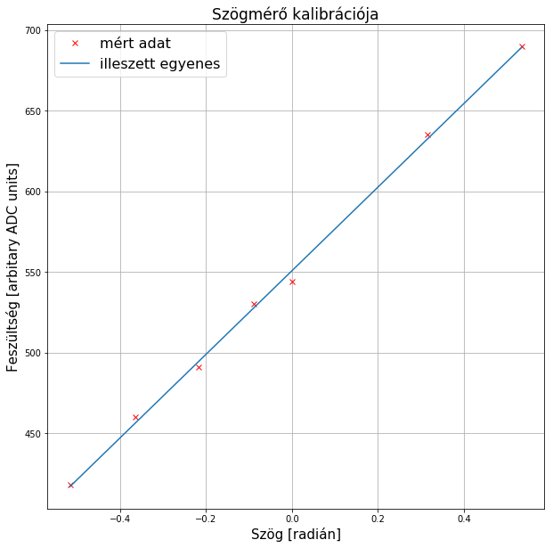

## 2. feladat

Normál lengés vizsgálata. Mérje meg az inga mozgását, majd illessze az alábbi üsszefüggés paramétereit a mérési adatokhoz különböző kezdeti feltételek mellett! Az illesztési paraméterek hibáit is adja meg!

$$\Theta(t) = \Theta_0 + \Theta_\mathrm{max} e^{-t/\tau} \sin(2 \pi t / T + \phi).$$

Késíztsen ábrákat, és gyűjtse táblázatba az illesztés paramétereit! Ügyeljen arra, hogy az előző feladat kalibrációs paramétereit figyelembe véve, ebben a feladatban a $\Theta$ a fizikailag természetesen értelmezhető radián egységekben legyen kifejtve.

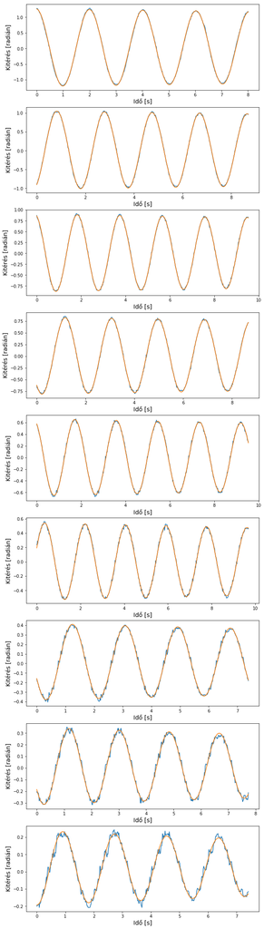

## 3. feladat

A lengési idő amplitúdófüggésének vizsgálata. Az alábbi összefüggés igazolásához az előző feladat illesztési paramétereire támaszkodva végezze el az elemzést. Készítsen ábrát és összegezze a tapasztalatait! Az illesztésnél vegye figyelembe a paraméterek hibáját is! Diszkuttálja az illesztés pontosságát!

$$T = T_0 \left(1 + \frac{\Theta^2_\mathrm{max}}{16} + \mathcal{O}(4)\right).$$

```
(9, 5) (9, 5)
[ 1.81359977 13.71641614] [0.00076107 0.09995077]
```

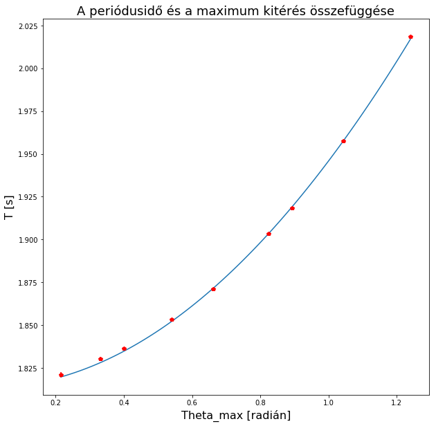

A periódusidőt tényleg jól jellemzi a négyzetes függvény, de az együtthatója (a négyzetes tagot osztó szám) jelentősen más lett: $13.71\pm0.1$ pedig $16$ kellene az elmélet szerint

## 4. feladat

Készítsen ábrát a $\tau(\Theta_\mathrm{max})$ kapcsolatról. Értelmezze az ábrát, a hibákat is figyelembe véve!

```
Text(0.5,1,'A csillapodás és a maximum kitérés összefüggése')
```

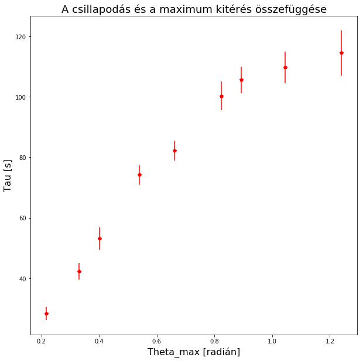

Egyértelműen az a trend figyelhető meg, hogy a nagyobb amplitúdójú rezgések lassabban csillapodnak. Mint azt a lenti numerikus megoldások illusztrálják, az egyik lehetséges magyarázat, hogy a súrlódási erő nem arányos a sebességgel. Az exponenciális csillapodás, amplitúdótól független időtényezővel a lináris súrlódásból jön ki, amilyet például a viszkózus közegben való nem túl gyors mozgás okoz.

Ha azonban a súrlódási erő nagyrészt szilárd testek érintkezésénél ered (az inga tengelyénél vagy a potméterben, például) akkor jobban modellezi egy a sebességgel ellentétes irányú, konstans nagyságú erő. Ha az így kapott lineáris burkológörbéjű rezgést próbáljuk meg exponenciálissal megilleszteni, mint az az alsó két ábrán látható, valóban a nagyobb kitérés fog lassabban csillapodni.

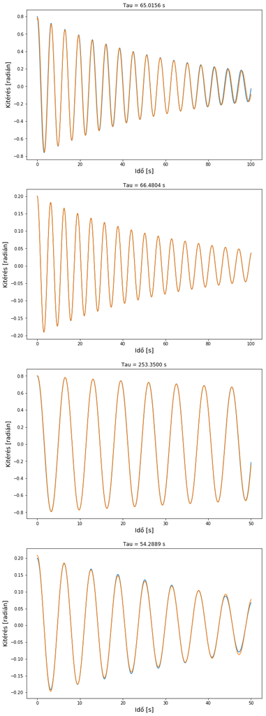